# single-cell RNA-seq analysis pipeline

This is the Seurat workflow applied to single-cell RNA sequencing data from multiple bladder cancer samples using the Seurat package in R. I have added some details in each step that will help to perform this pipeline from scractch. The goal is to read raw scRNA data, create a seurat object, perform quality control to filter out poor quality cells, merge and integrate multiple samples to correct for batch effect and lastly annotate cell clusters. The pipeline also contain the doublet finder (doublet cells) and ambiant RNA removal steps.

I have used four files, sample1 - sample4, in this workflow and processed each sample individually for more clarity.

## Required Libraries

```r
# Load the R packages for this workflow
library("dplyr")
library("ggplot2")
library("stringr")
library("Seurat")
library("Matrix")
library("tidyr")
library("scDblFinder")
library("SingleCellExperiment")
library("celda")
library("harmony")
library("scCustomize")
```

## Load Raw Expression Matrices

10X genomics is the most widely used single cell RNA sequencing platform. There are various RNA-seq quantification tools used which transform raw sequencing reads into a count matrix (genes x cells). Cell Ranger is the official 10X pipeline which uses STAR aligner to align and quantify raw reads into a count matrix. The CellRanger pipeline output scRNA raw data results in three files which together define the count matrix. These three files for each sample generated by the Cell Ranger pipeline includes:

- `matrix.mtx`: the raw count matrix
- `features.tsv`: gene names
- `barcodes.tsv`: cell barcodes .

We will use the feature, barcode, matrix files downloaded from a GEO study `GSE135337`, processed by the CellRAnger pipeline in this workflow. The code to read these files is demonstrated here. `ReadMtx` function will read these three files for each sample and convert into a single sparse matrix. Consider this count matrix of feature, barcode, matrix as a count matrix in bulk RNA-seq data. The rows are genes and columns are cell barcodes or cells. We will then convert this sparse count matrix into a seurat object.

```r
# Replace these paths with your own where your matrix, feature,barcode files for each sample are placed in your local computer

 sample1 <- ReadMtx(mtx = "path/to/sample1/matrix.mtx", features = "path/to/sample1/features.tsv",
  cells = "path/to/sample1/barcodes.tsv")

 sample2 <- ReadMtx(mtx = "path/to/sample2/matrix.mtx",features = "path/to/sample2/features.tsv",
  cells = "path/to/sample2/barcodes.tsv")

sample3 <- ReadMtx(mtx = "path/to/sample3/matrix.mtx", features = "path/to/sample3/features.tsv",
  cells = "path/to/sample3/barcodes.tsv")

sample4 <- ReadMtx(mtx = "path/to/sample4/matrix.mtx", features = "path/to/sample4/features.tsv",
  cells = "path/to/sample4/barcodes.tsv")
```

After running the above code each sample is transformed into a sparse matrix. I have uploaded the RDS files (carrying sparse matrix for each sample) in this repository.You can download these RDS files for each sample to run this workflow. RDS file is basically how we save any seurat object in R and can later use it again. I have provided the code to save and load RDS in the end. Here I am reading all the four RDS files uploaded in this repository with a for loop.

```r
files <- paste0("sample", 1:4, ".rds")
base_url <- "https://raw.githubusercontent.com/imranS86/single-cell-RNA-seq-pipeline/main/docs/"

for (i in seq_along(files)) {
  temp_file <- tempfile(fileext = ".rds")

  download.file(
    paste0(base_url, files[i]),
    temp_file,
    mode = "wb"
  )

  assign(
    paste0("sample", i),
    readRDS(temp_file),
    envir = .GlobalEnv
  )
}
```

```r
ls(pattern = "sample")
```

```
## [1] "sample1" "sample2" "sample3" "sample4"
```

## Create Seurat Objects

We now create individual Seurat objects for each sample from thier respective sparse matrix. Each object represent a single sample’s scRNA data. We apply basic quality control filter:

- `min.cells = 3`: Only keep genes expressed in at least 3 cells.
- `min.features = 200`: Only keep cells that have at least 200 detected genes (features).

In addition, we also calculate the percentage of mitrochondrial gene expression extracted by “^MT-” pattern from the data. This will create a new column `percent.mt` in the metadata that will demonstrate the mitochondrial percentage. Similarly, ribosomal percentage in each cell will be extracted by “^RPS|^RPL” pattern.

```r
  # Sample 1
  sample1 <- CreateSeuratObject(counts = sample1, project = "sample1", min.cells = 3, min.features = 200)
  sample1 <- PercentageFeatureSet(sample1, pattern = "^MT-", col.name = "percent.mt")
  sample1 <- PercentageFeatureSet(sample1, pattern = "^RPS|^RPL", col.name = "percent.ribo")

  # Sample 2
  sample2 <- CreateSeuratObject(counts = sample2, project = "sample2", min.cells = 3, min.features = 200)
  sample2 <- PercentageFeatureSet(sample2, pattern = "^MT-", col.name = "percent.mt")
  sample2 <- PercentageFeatureSet(sample2, pattern = "^RPS|^RPL", col.name = "percent.ribo")

  # Sample 3
  sample3 <- CreateSeuratObject(counts = sample3, project = "sample3", min.cells = 3, min.features = 200)
  sample3 <- PercentageFeatureSet(sample3, pattern = "^MT-", col.name = "percent.mt")
  sample3 <- PercentageFeatureSet(sample3, pattern = "^RPS|^RPL", col.name = "percent.ribo")

  # Sample 4
  sample4 <- CreateSeuratObject(counts = sample4, project = "sample4", min.cells = 3, min.features = 200)
  sample4 <- PercentageFeatureSet(sample4, pattern = "^MT-", col.name = "percent.mt")
  sample4 <- PercentageFeatureSet(sample4, pattern = "^RPS|^RPL", col.name = "percent.ribo")

  # View each of these Seurat objects metadata separately
  head(sample1@meta.data)
```

```
##                    orig.ident nCount_RNA nFeature_RNA percent.mt percent.ribo
## AAACCTGAGAAGAAGC.1    sample1      29186         5026   6.163914     23.19948
## AAACCTGAGCTACCTA.1    sample1      12107         2765   3.237796     24.58082
## AAACCTGCACGGCGTT.1    sample1      23767         4377   6.227122     28.38810
## AAACCTGCAGTCGTGC.1    sample1     112024         7377   2.893130     17.91223
## AAACCTGCATCTCGCT.1    sample1      17351         4329   1.429312     18.22373
## AAACCTGTCAGGCCCA.1    sample1      19601         3694   1.877455     11.91266
```

You will see new columns created in the metadata, which will be used for filtering in next step:

- `nCount_RNA`: Total number of unique molecules detected in a cell
- `nfeature_RNA`: Total number of unique genes in a cell
- `percent.mt`: mitochondrial percentage in each cell
- `percent.ribo`: ribosomal percentage in each cell

## Merge Seurat Objects

We’ll now merge all the four seurat objects for each sample into a single merged seurat object. This will help to perform integrated analysis (normalization, clustering, and downstream analysis).

```r
merged_seurat <- merge(sample1, y = c(sample2, sample3, sample4),
                       add.cell.ids = c("sample1", "sample2", "sample3", "sample4"),
                       project = "MergedProject")

head(merged_seurat)
```

```
##                            orig.ident nCount_RNA nFeature_RNA percent.mt
## sample1_AAACCTGAGAAGAAGC.1    sample1      29186         5026  6.1639142
## sample1_AAACCTGAGCTACCTA.1    sample1      12107         2765  3.2377963
## sample1_AAACCTGCACGGCGTT.1    sample1      23767         4377  6.2271216
## sample1_AAACCTGCAGTCGTGC.1    sample1     112024         7377  2.8931300
## sample1_AAACCTGCATCTCGCT.1    sample1      17351         4329  1.4293124
## sample1_AAACCTGTCAGGCCCA.1    sample1      19601         3694  1.8774552
## sample1_AAACCTGTCGGCGGTT.1    sample1      11514         2730  6.0882404
## sample1_AAACGGGCAGGTCCAC.1    sample1      10321         2798  0.9301424
## sample1_AAACGGGCATCCGGGT.1    sample1      54858         6048  1.7590871
## sample1_AAACGGGGTCATCGGC.1    sample1      14693         3403  5.3426802
##                            percent.ribo
## sample1_AAACCTGAGAAGAAGC.1     23.19948
## sample1_AAACCTGAGCTACCTA.1     24.58082
## sample1_AAACCTGCACGGCGTT.1     28.38810
## sample1_AAACCTGCAGTCGTGC.1     17.91223
## sample1_AAACCTGCATCTCGCT.1     18.22373
## sample1_AAACCTGTCAGGCCCA.1     11.91266
## sample1_AAACCTGTCGGCGGTT.1     25.60361
## sample1_AAACGGGCAGGTCCAC.1     22.69160
## sample1_AAACGGGCATCCGGGT.1     19.45204
## sample1_AAACGGGGTCATCGGC.1     15.79664
```

The add.cell.ids argument add the sample name to each cell barcode so that we can track which sample belong to which cell after merging seurat objects.

```r
# Add two new columns “Patient” and "Barcode" by separating the rownames (which contain cell barcode with its respective sample name) in the metadata for sample tracking
merged_seurat$sample <- rownames(merged_seurat@meta.data)
merged_seurat@meta.data <- separate(merged_seurat@meta.data, col = "sample", into = c("Patient", "Barcode"), sep = "_")

head(merged_seurat@meta.data)
```

```
##                            orig.ident nCount_RNA nFeature_RNA percent.mt
## sample1_AAACCTGAGAAGAAGC.1    sample1      29186         5026   6.163914
## sample1_AAACCTGAGCTACCTA.1    sample1      12107         2765   3.237796
## sample1_AAACCTGCACGGCGTT.1    sample1      23767         4377   6.227122
## sample1_AAACCTGCAGTCGTGC.1    sample1     112024         7377   2.893130
## sample1_AAACCTGCATCTCGCT.1    sample1      17351         4329   1.429312
## sample1_AAACCTGTCAGGCCCA.1    sample1      19601         3694   1.877455
##                            percent.ribo Patient            Barcode
## sample1_AAACCTGAGAAGAAGC.1     23.19948 sample1 AAACCTGAGAAGAAGC.1
## sample1_AAACCTGAGCTACCTA.1     24.58082 sample1 AAACCTGAGCTACCTA.1
## sample1_AAACCTGCACGGCGTT.1     28.38810 sample1 AAACCTGCACGGCGTT.1
## sample1_AAACCTGCAGTCGTGC.1     17.91223 sample1 AAACCTGCAGTCGTGC.1
## sample1_AAACCTGCATCTCGCT.1     18.22373 sample1 AAACCTGCATCTCGCT.1
## sample1_AAACCTGTCAGGCCCA.1     11.91266 sample1 AAACCTGTCAGGCCCA.1
```

After merging the samples into a single seurat object we can remove the individual samples from the environment to increase the memory space and processing efficiency.

```r
rm(sample1, sample2, sample3, sample4)
```

## Quality Control and Filtering

For quality control explore multiple metrics together. Don’t remove cells based on just one factor such as gene counts or UMI counts. Instead explore multiple metrics together including UMI counts, mitochondrial percentage, ribosomal percentage, number of detected genes. You might filter a dormant cell considering it as a dying cell. A dying cell has a high mitochondrial percentage and low UMI counts whereas a dormant cell has low UMI count but normal mitochondrial percentage. So we need to consider these factors during QC step.

We will first visualize the data to explore.

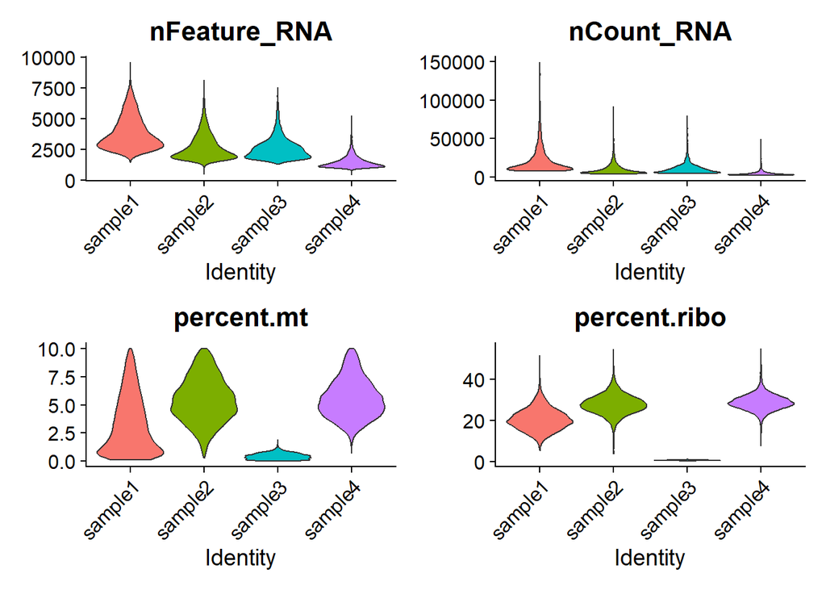

```r
VlnPlot(merged_seurat,
        features = c("nFeature_RNA", "nCount_RNA", "percent.mt", "percent.ribo"),
        pt.size= 0, ncol = 2)
```

Cells for each sample before filtering

```r
table(merged_seurat$Patient)
```

```
##
## sample1 sample2 sample3 sample4
##    3218    5006    3100    5131
```

```r
# Filtering Low quality cells
merged_seurat <- subset(merged_seurat, subset = nFeature_RNA > 200 & nFeature_RNA < 7500 & percent.mt < 10 & percent.ribo < 40)
```

The cut-off for `nFeature_RNA`, `percent.ribo` and `percent.mt` is not fix and depend on the data, that’s why it is important to explore your data and then select the cut-offs.

```r
# number of cells in each sample after filtering
table(merged_seurat$Patient)
```

```
##
## sample1 sample2 sample3 sample4
##    3190    4953    3099    5072
```

## Doublet removal

During single cell RNA sequencing (a droplet based technology), sometimes more than one cell get capture in a single droplet containing the transcriptome of two cells which badly interfere the analysis so it is handy practice to remove doublets. Here I use `scDblFinder` package that flags artificial doublet cells.

For doublet detection we will first convert the seurat object into a SingleCellExperiment (as scdblFinder package require input in this format).

```r
#joining layers as single cell experiment will take joined layers
merged_seurat[["RNA"]] <- JoinLayers(merged_seurat[["RNA"]])

# convert the seurat object into a  SingleCellExperiment
sce <- as.SingleCellExperiment(merged_seurat)
#samples parameter specify the metadata column with the sample IDs, if you have more than one sample
sce.dbl <- scDblFinder(sce, samples = "Patient")
```

[output not shown]

```r
colData(sce.dbl)
```

```
## DataFrame with 16314 rows and 13 columns
##                             orig.ident nCount_RNA nFeature_RNA percent.mt
##                            <character>  <numeric>    <integer>  <numeric>
## sample1_AAACCTGAGAAGAAGC.1     sample1      29186         5026    6.16391
## sample1_AAACCTGAGCTACCTA.1     sample1      12107         2765    3.23780
## sample1_AAACCTGCACGGCGTT.1     sample1      23767         4377    6.22712
## sample1_AAACCTGCAGTCGTGC.1     sample1     112024         7377    2.89313
## sample1_AAACCTGCATCTCGCT.1     sample1      17351         4329    1.42931
## ...                                ...        ...          ...        ...
## sample4_TTTGTCATCACTTATC.1     sample4       2909         1134    2.71571
## sample4_TTTGTCATCCGCATAA.1     sample4       2703         1103    4.03256
## sample4_TTTGTCATCCGGGTGT.1     sample4       2966         1148    2.93324
## sample4_TTTGTCATCGCTTGTC.1     sample4       3638         1248    4.17812
## sample4_TTTGTCATCTGTACGA.1     sample4       3435         1308    6.78311
##                            percent.ribo     Patient            Barcode    ident
##                               <numeric> <character>        <character> <factor>
## sample1_AAACCTGAGAAGAAGC.1      23.1995     sample1 AAACCTGAGAAGAAGC.1  sample1
## sample1_AAACCTGAGCTACCTA.1      24.5808     sample1 AAACCTGAGCTACCTA.1  sample1
## sample1_AAACCTGCACGGCGTT.1      28.3881     sample1 AAACCTGCACGGCGTT.1  sample1
## sample1_AAACCTGCAGTCGTGC.1      17.9122     sample1 AAACCTGCAGTCGTGC.1  sample1
## sample1_AAACCTGCATCTCGCT.1      18.2237     sample1 AAACCTGCATCTCGCT.1  sample1
## ...                                 ...         ...                ...      ...
## sample4_TTTGTCATCACTTATC.1      28.0509     sample4 TTTGTCATCACTTATC.1  sample4
## sample4_TTTGTCATCCGCATAA.1      23.3814     sample4 TTTGTCATCCGCATAA.1  sample4
## sample4_TTTGTCATCCGGGTGT.1      28.5907     sample4 TTTGTCATCCGGGTGT.1  sample4
## sample4_TTTGTCATCGCTTGTC.1      27.4052     sample4 TTTGTCATCGCTTGTC.1  sample4
## sample4_TTTGTCATCTGTACGA.1      28.9956     sample4 TTTGTCATCTGTACGA.1  sample4
##                            scDblFinder.sample scDblFinder.class
##                                      <factor>          <factor>
## sample1_AAACCTGAGAAGAAGC.1            sample1           singlet
## sample1_AAACCTGAGCTACCTA.1            sample1           singlet
## sample1_AAACCTGCACGGCGTT.1            sample1           singlet
## sample1_AAACCTGCAGTCGTGC.1            sample1           singlet
## sample1_AAACCTGCATCTCGCT.1            sample1           singlet
## ...                                       ...               ...
## sample4_TTTGTCATCACTTATC.1            sample4           singlet
## sample4_TTTGTCATCCGCATAA.1            sample4           singlet
## sample4_TTTGTCATCCGGGTGT.1            sample4           singlet
## sample4_TTTGTCATCGCTTGTC.1            sample4           singlet
## sample4_TTTGTCATCTGTACGA.1            sample4           singlet
```

[output cut: 11 more lines]

```
## sample4_TTTGTCATCGCTTGTC.1       0.001176010             0.268353
## sample4_TTTGTCATCTGTACGA.1       0.001094205             0.331268
##                            scDblFinder.cxds_score
##                                         <numeric>
## sample1_AAACCTGAGAAGAAGC.1              0.2550845
## sample1_AAACCTGAGCTACCTA.1              0.1642875
## sample1_AAACCTGCACGGCGTT.1              0.0904029
## sample1_AAACCTGCAGTCGTGC.1              0.5096186
## sample1_AAACCTGCATCTCGCT.1              0.0340535
## ...                                           ...
## sample4_TTTGTCATCACTTATC.1              0.0035873
## sample4_TTTGTCATCCGCATAA.1              0.3976597
## sample4_TTTGTCATCCGGGTGT.1              0.4305182
## sample4_TTTGTCATCGCTTGTC.1              0.0799788
## sample4_TTTGTCATCTGTACGA.1              0.0010673
```

Now we will transfer the doublet scores from sce object into our suerat object. First check the cell barcodes are in the same order in both these datasets.

```r
all.equal(colData(sce.dbl) %>% row.names(), merged_seurat@meta.data %>% row.names())
```

```
## [1] TRUE
```

```r
merged_seurat$scDblFinder.score<- sce.dbl$scDblFinder.score
merged_seurat$scDblFinder.class<- sce.dbl$scDblFinder.class
head(merged_seurat@meta.data)
```

```
##                            orig.ident nCount_RNA nFeature_RNA percent.mt
## sample1_AAACCTGAGAAGAAGC.1    sample1      29186         5026   6.163914
## sample1_AAACCTGAGCTACCTA.1    sample1      12107         2765   3.237796
## sample1_AAACCTGCACGGCGTT.1    sample1      23767         4377   6.227122
## sample1_AAACCTGCAGTCGTGC.1    sample1     112024         7377   2.893130
## sample1_AAACCTGCATCTCGCT.1    sample1      17351         4329   1.429312
## sample1_AAACCTGTCAGGCCCA.1    sample1      19601         3694   1.877455
##                            percent.ribo Patient            Barcode
## sample1_AAACCTGAGAAGAAGC.1     23.19948 sample1 AAACCTGAGAAGAAGC.1
## sample1_AAACCTGAGCTACCTA.1     24.58082 sample1 AAACCTGAGCTACCTA.1
## sample1_AAACCTGCACGGCGTT.1     28.38810 sample1 AAACCTGCACGGCGTT.1
## sample1_AAACCTGCAGTCGTGC.1     17.91223 sample1 AAACCTGCAGTCGTGC.1
## sample1_AAACCTGCATCTCGCT.1     18.22373 sample1 AAACCTGCATCTCGCT.1
## sample1_AAACCTGTCAGGCCCA.1     11.91266 sample1 AAACCTGTCAGGCCCA.1
##                            scDblFinder.score scDblFinder.class
## sample1_AAACCTGAGAAGAAGC.1       0.170460105           singlet
## sample1_AAACCTGAGCTACCTA.1       0.009476569           singlet
## sample1_AAACCTGCACGGCGTT.1       0.315040767           singlet
## sample1_AAACCTGCAGTCGTGC.1       0.070115976           singlet
## sample1_AAACCTGCATCTCGCT.1       0.008992366           singlet
## sample1_AAACCTGTCAGGCCCA.1       0.624697030           singlet
```

Explore how many doublets were detected

```r
table(merged_seurat$scDblFinder.class)
```

```
##
## singlet doublet
##   15334     980
```

Retain only singlet cells

```r
merged_seurat <- merged_seurat[, merged_seurat$scDblFinder.class == "singlet"]
```

## Ambiant RNA removal

In single cell RNA sequencing during droplet capture cells are lysed as a result their mRNA spread to nearby cells. This solution referred as “ambient RNA” is added to each cell contaminating the expression profile. For instance you get an immune cell cluster with high epithelial markers, you might call it epithelial cell when really it is just an immune cell with high epithelial genes because of the ambient RNA contamination.

Here we use `decontX`, a tool for ambient RNA removal. decontX also need a single cell experiment object.

```r
#Extract counts from the merged Seurat Object
raw_counts <- GetAssayData(merged_seurat, slot = "counts")

#Convert into Single Cell Experiment and run decontX
sce_decontx <- SingleCellExperiment(list(counts= raw_counts))
sce_decontx <- decontX(sce_decontx)

#optional check contamination per cell
contamination <- colData(sce_decontx)$decontX_contamination

#Add decontaminated counts to Seurat
decount_counts <- round(decontXcounts(sce_decontx))
merged_seurat[["decontXcounts"]] <- CreateAssayObject(counts = decount_counts)
#Add contamination to metada
merged_seurat$decontX_contamination <- contamination

#set new default assay to decontaminated counts
DefaultAssay(merged_seurat) <- "decontXcounts"

DefaultAssay(merged_seurat)
```

```
## [1] "decontXcounts"
```

I want to use the “decontXcounts” as the default assay for the rest of the analysis, so to avoid any confusion I want to remove the “RNA” assay from the seurat object.

```r
merged_seurat[["RNA"]] <- NULL
```

## Seurat standard workflow

### Preprocessing for PCA and clustering (Before Integration)

Seurat workflow involves normalizing the raw counts, identifying the highly variable genes (top 2000 by default in each cell), scale the data so that it is comparable across cells and samples.

We first create another seurat object that we will need to run seurat workflow from scratch later. So we will create another seurat object “merged_integrated_seurat” here.

```r
merged_integrated_seurat <- merged_seurat
```

```r
# Normalize gene expression counts using log-normalization
merged_seurat <- NormalizeData(merged_seurat)

# Identify 2000 highly variable genes (used for downstream steps like PCA) in each cell
merged_seurat <- FindVariableFeatures(merged_seurat)

# Scale and centering the data (zero-mean, unit variance)
merged_seurat <- ScaleData(merged_seurat)

# Run Principal Component Analysis (PCA) to reduce dimensionality
merged_seurat <- RunPCA(merged_seurat)
```

### Determine Optimal Number of Principal Components

Choosing the right number of Principal Components (PCs) is crucial for clustering and integration. Seurat suggest Elbow Plot for this purpose.

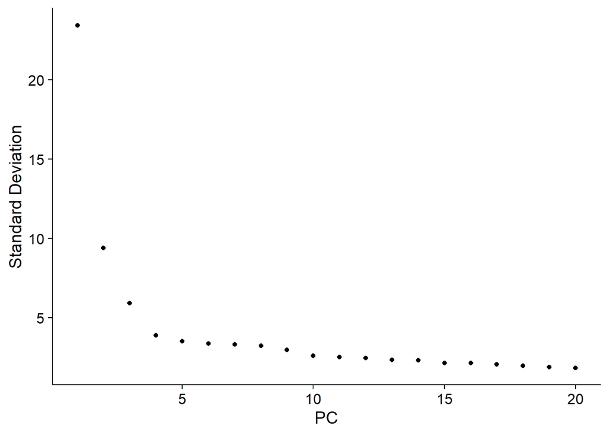

```r
# Visual inspection using elbow plot
ElbowPlot(merged_seurat, ndims = 20)
```

In addition to elbow plot, I use a heuristic method to select PCs taken from Hamid Ghaedi: https://github.com/hamidghaedi/scRNA_seq-analysis. Too few PCs can miss meaningful clusters, too many include noise. We select PCs capturing most variance. You can just use the elbow plot but I also use this heuristic method to get the exact optimal PCs to proceed (but this is optional step).

```r
# Heuristic approach to select PCs
pct <- merged_seurat[["pca"]]@stdev / sum(merged_seurat[["pca"]]@stdev) * 100
cumu <- cumsum(pct)
co1 <- which(cumu > 90 & pct < 5)[1]
co2 <- sort(which((pct[1:length(pct) - 1] - pct[2:length(pct)]) > 0.1), decreasing = TRUE)[1] + 1
pcs <- min(co1, co2)
pcs #return the optimal PCs
```

```
## [1] 15
```

### Clustering without integration

We cluster cells based on selected PCs identified in the previous step and use UMAP to visualize batch effects before the integration step. This helps us to see the clustering pattern and how much batch effect might exist.

```r
merged_seurat <- FindNeighbors(merged_seurat, dims = 1:15, reduction = "pca")
merged_seurat <- FindClusters(merged_seurat, resolution = 0.4, cluster.name = "unintegrated_clusters")
```

```
## Modularity Optimizer version 1.3.0 by Ludo Waltman and Nees Jan van Eck
##
## Number of nodes: 15334
## Number of edges: 496580
##
## Running Louvain algorithm...
## Maximum modularity in 10 random starts: 0.9140
## Number of communities: 11
## Elapsed time: 2 seconds
```

```r
merged_seurat <- RunUMAP(merged_seurat, dims = 1:15, reduction = "pca", reduction.name = "umap.unintegrated")

head(merged_seurat@meta.data[,c(1:3,12:14)])
```

```
##                            orig.ident nCount_RNA nFeature_RNA
## sample1_AAACCTGAGAAGAAGC.1    sample1      29186         5026
## sample1_AAACCTGAGCTACCTA.1    sample1      12107         2765
## sample1_AAACCTGCACGGCGTT.1    sample1      23767         4377
## sample1_AAACCTGCAGTCGTGC.1    sample1     112024         7377
## sample1_AAACCTGCATCTCGCT.1    sample1      17351         4329
## sample1_AAACCTGTCAGGCCCA.1    sample1      19601         3694
##                            decontX_contamination unintegrated_clusters
## sample1_AAACCTGAGAAGAAGC.1           0.006437249                     2
## sample1_AAACCTGAGCTACCTA.1           0.004695976                     2
## sample1_AAACCTGCACGGCGTT.1           0.006043906                     2
## sample1_AAACCTGCAGTCGTGC.1           0.002991271                     2
## sample1_AAACCTGCATCTCGCT.1           0.017679161                     6
## sample1_AAACCTGTCAGGCCCA.1           0.002908243                     2
##                            seurat_clusters
## sample1_AAACCTGAGAAGAAGC.1               2
## sample1_AAACCTGAGCTACCTA.1               2
## sample1_AAACCTGCACGGCGTT.1               2
## sample1_AAACCTGCAGTCGTGC.1               2
## sample1_AAACCTGCATCTCGCT.1               6
## sample1_AAACCTGTCAGGCCCA.1               2
```

### Plot to visualize cells based on patient samples

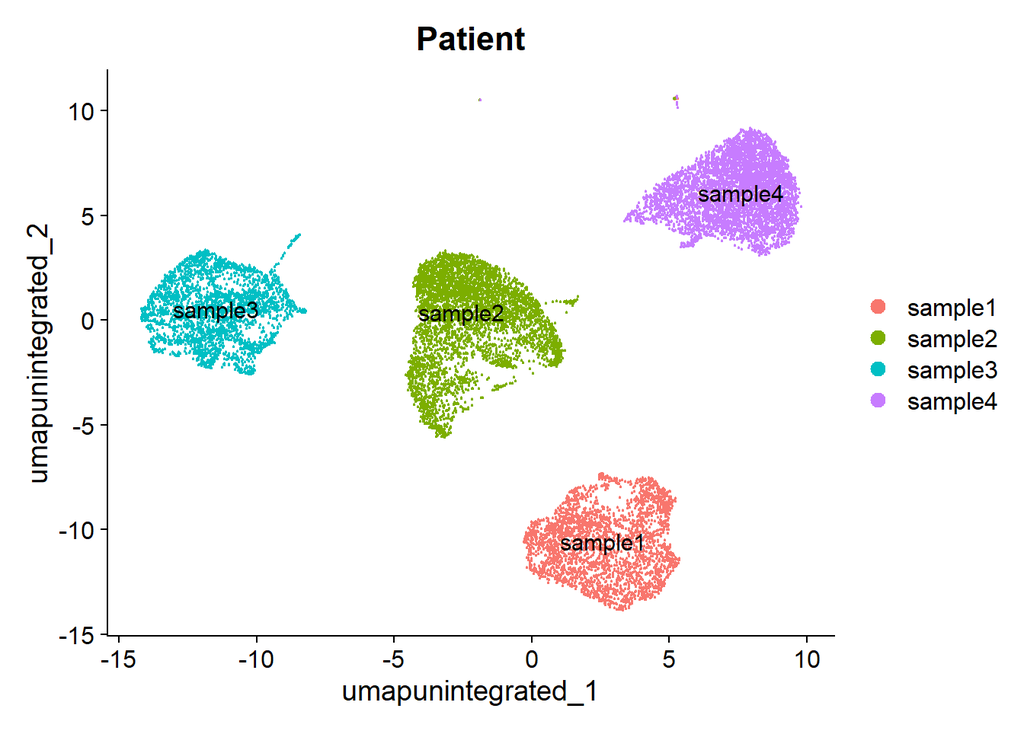

```r
uninregrated <- DimPlot(merged_seurat, reduction = "umap.unintegrated", group.by = "Patient", label = TRUE)

uninregrated
```

### Integrate samples with Harmony

Different samples might have batch effects due to technical variation (e.g processed on different days, different sequencing machines or processed in different labs). Seurat provides various integration methods such as Harmony, Canonical Correlation Analysis (CCA), RPCA to integrate different samples and reduce technical noise.

I use harmony here. As suggested by Ming Tang that “Harmony is fast, simple and works well for batch correction. It works on PC embeddings and identify cells which should be similar across batches, learns correction factors and adjust embeddings to remove batch effects while preserving real biology. For details about whether you need integration or not for your dataset, read the singlle cell guide by Tommy Tang: https://crazyhottommy.github.io/practical_scRNAseq_analysis_with_R/seurat-workflow.html

Here we will run the seurat standard workflow again to integrate samples using harmony in a single code block using %>% operatior in dplyr R package to minimize batch effect. we will use the “merged_integrated_seurat” object we created above.

```r
merged_integrated_seurat <- merged_integrated_seurat %>%
  NormalizeData(normalization.method = "LogNormalize", scale.factor = 10000) %>%
  FindVariableFeatures(selection.method = "vst", nfeatures = 2000) %>%
  ScaleData() %>%
  RunPCA() %>%
  RunHarmony(group.by.vars = "Patient", dims.use = 1:15) %>%
  RunUMAP(reduction = "harmony", dims = 1:15) %>%
  FindNeighbors(reduction = "harmony", dims = 1:15) %>%
  FindClusters(resolution = 0.4)
```

```
## Modularity Optimizer version 1.3.0 by Ludo Waltman and Nees Jan van Eck
##
## Number of nodes: 15334
## Number of edges: 468255
##
## Running Louvain algorithm...
## Maximum modularity in 10 random starts: 0.8867
## Number of communities: 11
## Elapsed time: 2 seconds
```

After integration explore UMAP plot on PCs corrected by Harmony

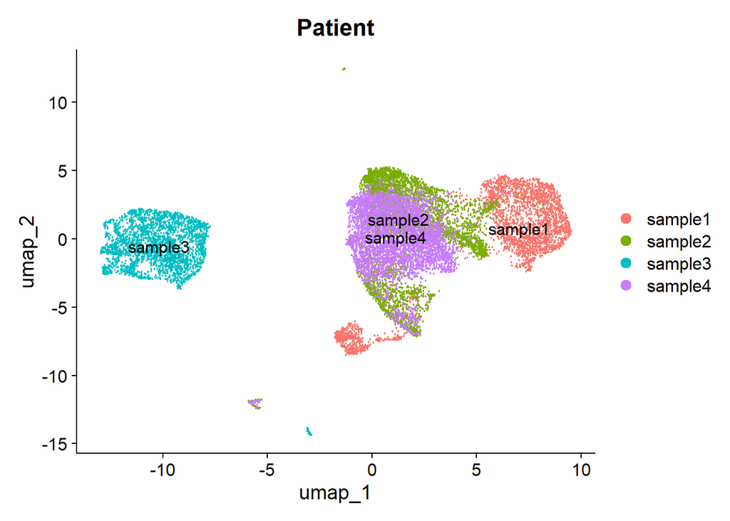

```r
DimPlot(merged_integrated_seurat, group.by = "Patient", label = TRUE)
```

## Cell Annotation by marker genes

After getting the cell clusters we now need to annotate these clusters. Cell annotation is the trickiest step of single cell RNA workflow as there are hundreds of cell annotation methods so it is very hard to agree which is the most reliable method. Generally the most trustworthy method is manual where you use known marker genes based on literature data to annotate cells.

In addition there are reference based tools such as SingleR where cells are compared based on pre-annotated reference datasets. Senior computational biologists suggest to use both approaches. Use tools to have a general idea and then validate with marker genes instead of merely using a single approach. Here I use the manual marker based approach to annotate cells.

Based on literature data (previous studies and databases) we define the markers for major cell types.

```r
# define marker genes for major cell types
markers <- list(
  "epithelial" = c("EPCAM", "KRT17", "KRT18", "KRT5", "SFN"),
  "endothelial" = c("CLDN5","PECAM1","VWF"),
  "Fibroblast" = c("COL1A1","PDGFRA","COL1A2", "LUM","THY1"),
  "Myeloid" = c("CD14","LYZ","C1QB","FCGR3A"),
  "T-Cells" = c("CD3D",'CD3E'),
  "B-Cell" = c("CD79A"),
  "other" =c("MYL9","MCAM", "VIM", "PTPRC","FN1")
)
```